# MER Hardship Waiver Data Analysis

2025-04-01

Introduction This report analyzes Medicaid estate recovery trends in four states using FY 2019 data. It focuses on the relationship between recovery rates, hardship waiver policies, and socioeconomic factors.

```r
#Libraries
packages <- c("readr", "ggplot2", "scales", "ggrepel", "tidyr", "dplyr")
installed <- packages %in% rownames(installed.packages())
if (any(!installed)) {
  install.packages(packages[!installed])
}
invisible(lapply(packages, library, character.only = TRUE))
#Data
url <- "https://raw.githubusercontent.com/AinsGalla/MER/main/MER%20Strat%202%20-%20Data%20Set%20Analysis%201%20(1).csv"
MER_Data <- read_csv(url)
```

```
## `curl` package not installed, falling back to using `url()`
##
```

```r
head(MER_Data)
```

```
## # A tibble: 4 × 13
##   State     Estate Recovery % of…¹ `Poverty Rate 65+ (%)` Homeownership Rate 6…²
##   <chr>                      <dbl>                  <dbl>                  <dbl>
## 1 Californ…                   0.59                   12                     72.9
## 2 Texas                       0.11                   13.6                   80.3
## 3 Mississi…                   0.02                   19.6                   85
## 4 Massachu…                   1.7                     9.4                   71.8
## # ℹ abbreviated names: ¹`Estate Recovery % of LTSS Spending`,
## #   ²`Homeownership Rate 65+ (%)`
## # ℹ 9 more variables: `Median HH Income ($)` <dbl>, `GINI Coefficient` <dbl>,
## #   B_Accessibility <dbl>, C_Clarity <dbl>, D_ModeOfComm <dbl>,
## #   E_PublicEdEfforts <dbl>, F_ScopeOfWaiver <dbl>, G_LegalAdminBurden <dbl>,
## #   Waiver_Protectiveness_Score <dbl>
```

Data Citations Medicaid and CHIP Payment and Access Commission (MACPAC). (2023). Medicaid estate recovery: Improving policy and promoting equity. (Appendix 3, Table 3E-1). Retrieved from https://www.macpac.gov/publication/ch-3-medicaid-estate-recovery-improving-policy-and-promoting-equity/ National Center for Education Statistics. (2020). Median household income, by state: Selected years, 1990 through 2019. (Table 102.30). Retrieved from https://nces.ed.gov/programs/digest/d20/tables/dt20_102.30.asp United States Census Bureau. (2019). 2019 poverty rate in the United States. Retrieved from https://www.census.gov/library/visualizations/interactive/2019-poverty-rate.html Urban.org.(n.d.). Forecasting state and national trends in household formation and homeownership: California. Retrieved from https://www.urban.org/policy-centers/housing-finance-policy-center/projects/forecasting-state-and-national-trends-household-formation-and-homeownership/california Urban.org.(n.d.). Forecasting state and national trends in household formation and homeownership: Texas. Retrieved from https://www.urban.org/policy-centers/housing-finance-policy-center/projects/forecasting-state-and-national-trends-household-formation-and-homeownership/texas

Page 19, correlation matrix focused on the relationship between several key variables and Estate Recovery as a % of LTSS (Long-Term Services and Supports) Spending

```r
#Correlation Matrix
summary(MER_Data)
```

```
##     State           Estate Recovery % of LTSS Spending Poverty Rate 65+ (%)
##  Length:4           Min.   :0.0200                     Min.   : 9.40
##  Class :character   1st Qu.:0.0875                     1st Qu.:11.35
##  Mode  :character   Median :0.3500                     Median :12.80
##                     Mean   :0.6050                     Mean   :13.65
##                     3rd Qu.:0.8675                     3rd Qu.:15.10
##                     Max.   :1.7000                     Max.   :19.60
##  Homeownership Rate 65+ (%) Median HH Income ($) GINI Coefficient
##  Min.   :71.80              Min.   :45800        Min.   :0.480
##  1st Qu.:72.62              1st Qu.:59450        1st Qu.:0.480
##  Median :76.60              Median :72200        Median :0.485
##  Mean   :77.50              Mean   :69000        Mean   :0.485
##  3rd Qu.:81.47              3rd Qu.:81750        3rd Qu.:0.490
##  Max.   :85.00              Max.   :85800        Max.   :0.490
##  B_Accessibility   C_Clarity     D_ModeOfComm  E_PublicEdEfforts
##  Min.   :3.00    Min.   :1.00   Min.   :2.00   Min.   :0.00
##  1st Qu.:3.75    1st Qu.:1.75   1st Qu.:2.75   1st Qu.:0.75
##  Median :4.50    Median :2.00   Median :3.50   Median :1.00
##  Mean   :4.25    Mean   :1.75   Mean   :3.50   Mean   :0.75
##  3rd Qu.:5.00    3rd Qu.:2.00   3rd Qu.:4.25   3rd Qu.:1.00
##  Max.   :5.00    Max.   :2.00   Max.   :5.00   Max.   :1.00
##  F_ScopeOfWaiver G_LegalAdminBurden Waiver_Protectiveness_Score
##  Min.   :2.0     Min.   :3.00       Min.   :12.00
##  1st Qu.:3.5     1st Qu.:3.00       1st Qu.:12.75
##  Median :4.5     Median :3.00       Median :16.00
##  Mean   :4.0     Mean   :3.25       Mean   :16.00
##  3rd Qu.:5.0     3rd Qu.:3.25       3rd Qu.:19.25
##  Max.   :5.0     Max.   :4.00       Max.   :20.00
```

```r
cor(MER_Data[, sapply(MER_Data, is.numeric)], use = "complete.obs")
```

```
##                                    Estate Recovery % of LTSS Spending
## Estate Recovery % of LTSS Spending                          1.0000000
## Poverty Rate 65+ (%)                                       -0.8069544
## Homeownership Rate 65+ (%)                                 -0.8236809
## Median HH Income ($)                                        0.8209896
## GINI Coefficient                                           -0.4489001
## B_Accessibility                                             0.7105795
## C_Clarity                                                   0.4276348
## D_ModeOfComm                                                0.9234695
## E_PublicEdEfforts                                           0.5053866
## F_ScopeOfWaiver                                             0.6872352
## G_LegalAdminBurden                                         -0.4276348
## Waiver_Protectiveness_Score                                 0.8633833
##                                    Poverty Rate 65+ (%)
## Estate Recovery % of LTSS Spending         -0.806954407
## Poverty Rate 65+ (%)                        1.000000000
## Homeownership Rate 65+ (%)                  0.938065159
## Median HH Income ($)                       -0.973879111
## GINI Coefficient                            0.573639356
## B_Accessibility                            -0.470608756
## C_Clarity                                   0.007702112
## D_ModeOfComm                               -0.960530938
## E_PublicEdEfforts                          -0.916551385
## F_ScopeOfWaiver                            -0.969426441
## G_LegalAdminBurden                         -0.007702112
## Waiver_Protectiveness_Score                -0.860300795
##                                    Homeownership Rate 65+ (%)
## Estate Recovery % of LTSS Spending                 -0.8236809
## Poverty Rate 65+ (%)                                0.9380652
## Homeownership Rate 65+ (%)                          1.0000000
## Median HH Income ($)                               -0.9920542
## GINI Coefficient                                    0.2672612
## B_Accessibility                                    -0.7280194
## C_Clarity                                          -0.2979651
## D_ModeOfComm                                       -0.9685473
## E_PublicEdEfforts                                  -0.7981208
## F_ScopeOfWaiver                                    -0.9518815
## G_LegalAdminBurden                                  0.2979651
## Waiver_Protectiveness_Score                        -0.9774943
##                                    Median HH Income ($) GINI Coefficient
```

[output cut: 49 more lines]

```
## G_LegalAdminBurden                        1.000000000
## Waiver_Protectiveness_Score              -0.489897949
##                                    Waiver_Protectiveness_Score
## Estate Recovery % of LTSS Spending                   0.8633833
## Poverty Rate 65+ (%)                                -0.8603008
## Homeownership Rate 65+ (%)                          -0.9774943
## Median HH Income ($)                                 0.9472757
## GINI Coefficient                                    -0.1414214
## B_Accessibility                                      0.8528029
## C_Clarity                                            0.4898979
## D_ModeOfComm                                         0.9486833
## E_PublicEdEfforts                                    0.6531973
## F_ScopeOfWaiver                                      0.8660254
## G_LegalAdminBurden                                  -0.4898979
## Waiver_Protectiveness_Score                          1.0000000
```

Page 20, Medicaid estate recovery intensity across four states in FY 2019

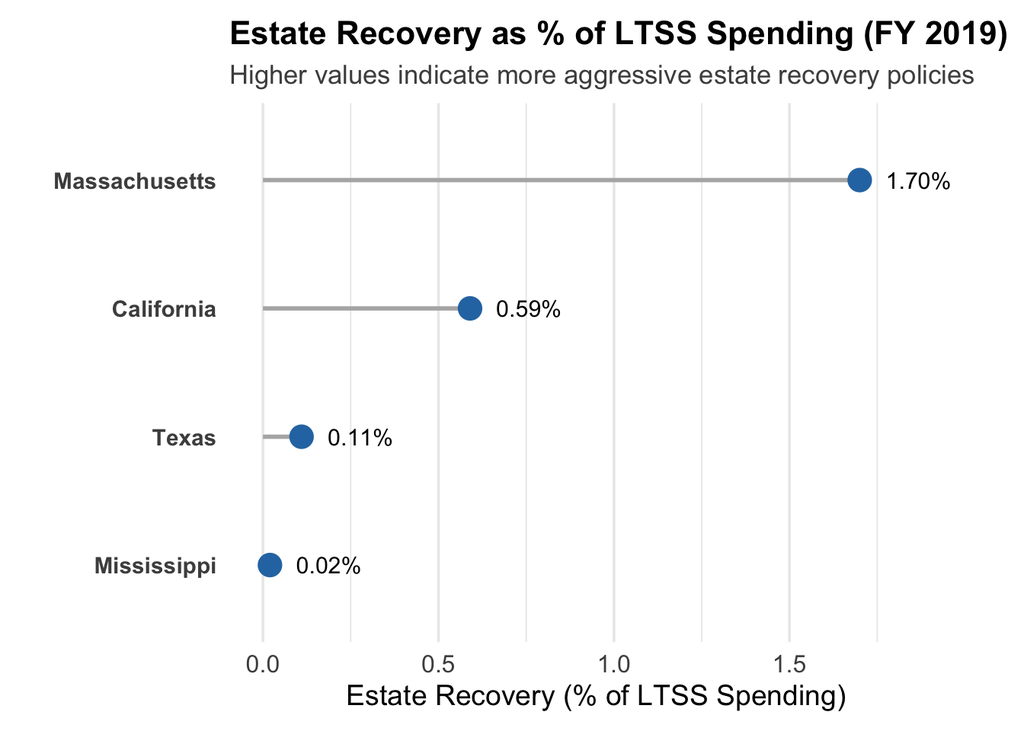

```r
#Figure 1
ggplot(MER_Data, aes(x = reorder(State, `Estate Recovery % of LTSS Spending`),
                 y = `Estate Recovery % of LTSS Spending`)) +
  geom_segment(aes(xend = reorder(State, `Estate Recovery % of LTSS Spending`),
                   yend = 0), color = "gray70", linewidth = 1) +
  geom_point(size = 5, color = "#2C77B2") +
  geom_text(aes(label = percent(`Estate Recovery % of LTSS Spending` / 100, accuracy = 0.01)),
            hjust = -0.4, size = 4) +
  coord_flip(clip = "off") +
  expand_limits(y = max(MER_Data$`Estate Recovery % of LTSS Spending`) + 0.2) +
  labs(
    title = "Estate Recovery as % of LTSS Spending (FY 2019)",
    subtitle = "Higher values indicate more aggressive estate recovery policies",
    x = "",
    y = "Estate Recovery (% of LTSS Spending)"
  ) +
  theme_minimal(base_size = 14) +
  theme(
    plot.title = element_text(face = "bold", size = 16),
    plot.subtitle = element_text(size = 13, color = "gray30"),
    axis.text.y = element_text(face = "bold"),
    axis.text.x = element_text(size = 12),
    panel.grid.major.y = element_blank(),
    plot.margin = margin(10, 30, 10, 10)
  )
```

Page 21, The inverse relationship between state poverty rates and the share of LTSS spending recovered through Estate Recovery.

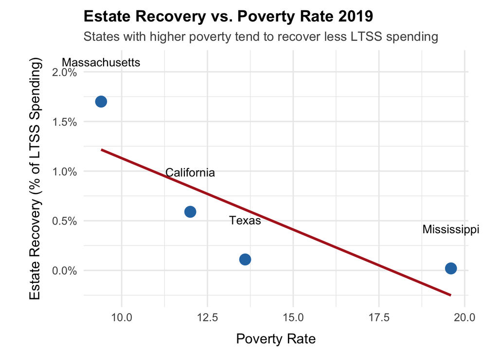

```r
#Figure 2
ggplot(MER_Data, aes(x = `Poverty Rate 65+ (%)`, y = `Estate Recovery % of LTSS Spending`, label = State)) +
  geom_point(size = 5, color = "#2C77B2") +
  geom_text(nudge_y = 0.4, size = 4.2, check_overlap = TRUE) +  # label offset above the point
  geom_smooth(method = "lm", se = FALSE, color = "firebrick", linewidth = 1.2) +
  scale_y_continuous(labels = scales::percent_format(scale = 1, accuracy = 0.1)) +
  labs(
    title = "Estate Recovery vs. Poverty Rate 2019",
    subtitle = "States with higher poverty tend to recover less LTSS spending",
    x = "Poverty Rate",
    y = "Estate Recovery (% of LTSS Spending)"
  ) +
  coord_cartesian(clip = "off") +
  theme_minimal(base_size = 14) +
  theme(
    plot.title = element_text(face = "bold", size = 16),
    plot.subtitle = element_text(size = 13, color = "gray30"),
    axis.title.x = element_text(margin = margin(t = 10)),
    axis.title.y = element_text(margin = margin(r = 10)),
    plot.margin = margin(10, 30, 10, 30)
  )
```

Page 22, The negative relationship between senior homeownership and Estate Recovery rates.

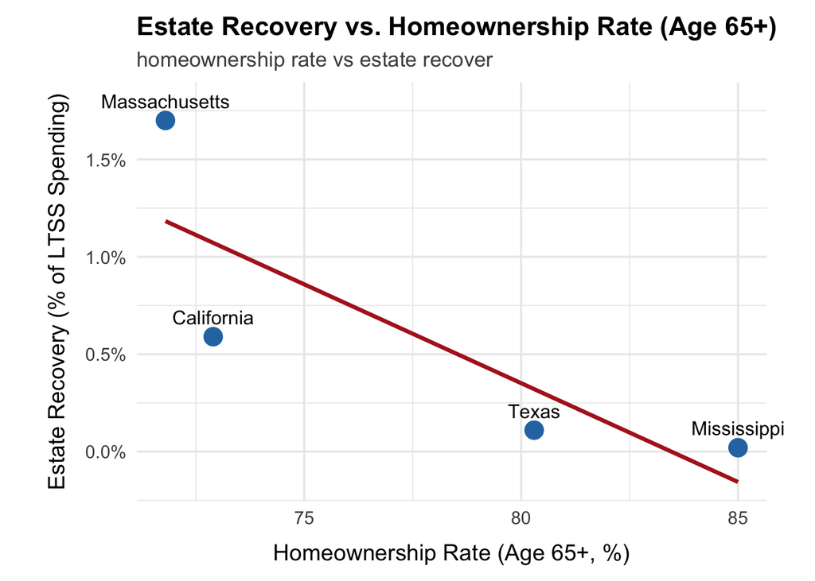

```r
#Figure 3
ggplot(MER_Data, aes(x = `Homeownership Rate 65+ (%)`, y = `Estate Recovery % of LTSS Spending`, label = State)) +
  geom_point(size = 5, color = "#2C77B2") +
  geom_text(nudge_y = 0.1, size = 4.2) +
  geom_smooth(method = "lm", se = FALSE, color = "firebrick", linewidth = 1.2) +
  scale_y_continuous(labels = percent_format(scale = 1, accuracy = 0.1)) +
  labs(
    title = "Estate Recovery vs. Homeownership Rate (Age 65+)",
    subtitle = "homeownership rate vs estate recover",
    x = "Homeownership Rate (Age 65+, %)",
    y = "Estate Recovery (% of LTSS Spending)"
  ) +
  coord_cartesian(clip = "off") +
  theme_minimal(base_size = 14) +
  theme(
    plot.title = element_text(face = "bold", size = 16),
    plot.subtitle = element_text(size = 13, color = "gray30"),
    axis.title.x = element_text(margin = margin(t = 10)),
    axis.title.y = element_text(margin = margin(r = 10)),
    plot.margin = margin(10, 30, 10, 30)
  )
```

Page 23, Hardship waiver protectiveness score

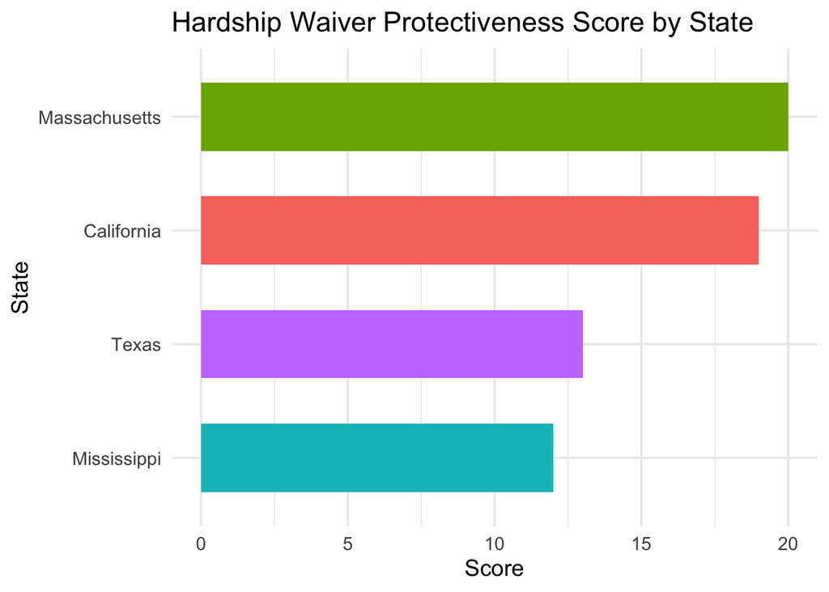

```r
#Figure 4
ggplot(MER_Data, aes(x = reorder(State, Waiver_Protectiveness_Score),
                     y = Waiver_Protectiveness_Score, fill = State)) +
  geom_bar(stat = "identity", width = 0.6, show.legend = FALSE) +
  coord_flip() +
  labs(
    title = "Hardship Waiver Protectiveness Score by State",
    x = "State",
    y = "Score"
  ) +
  theme_minimal(base_size = 14)
```

Page 24, Hardship Waiver Policy Components by State

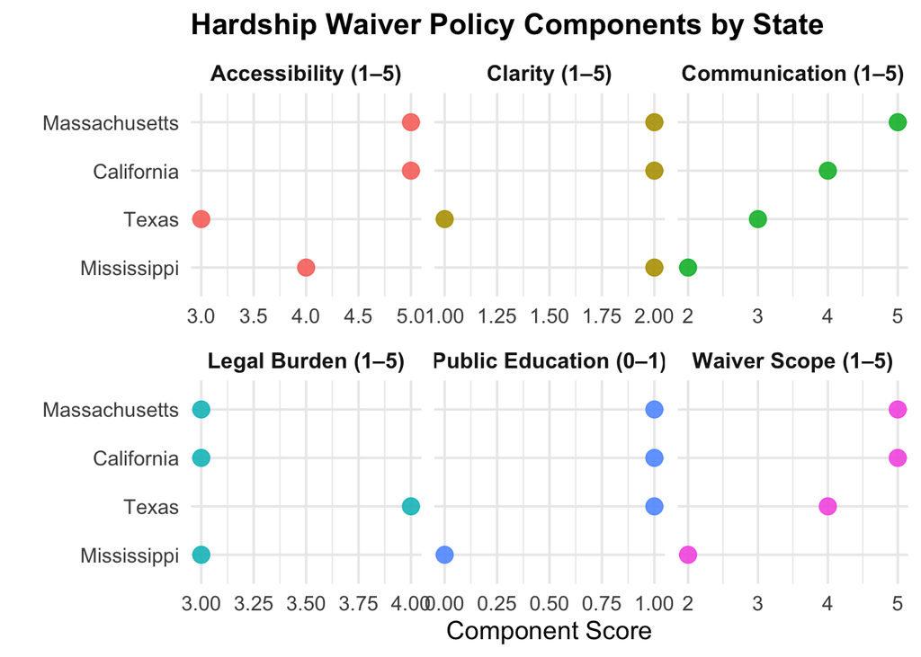

```r
#Figure 5
waiver_long <- MER_Data %>%
  select(State,
         B_Accessibility,
         C_Clarity,
         D_ModeOfComm,
         E_PublicEdEfforts,
         F_ScopeOfWaiver,
         G_LegalAdminBurden) %>%
  pivot_longer(-State, names_to = "Component", values_to = "Score")


waiver_long$Component <- recode(waiver_long$Component,
  B_Accessibility = "Accessibility (1–5)",
  C_Clarity = "Clarity (1–5)",
  D_ModeOfComm = "Communication (1–5)",
  E_PublicEdEfforts = "Public Education (0–1)",
  F_ScopeOfWaiver = "Waiver Scope (1–5)",
  G_LegalAdminBurden = "Legal Burden (1–5)"
)


p <- ggplot(waiver_long, aes(x = Score, y = reorder(State, Score), color = Component)) +
  geom_point(size = 4, alpha = 0.9) +
  facet_wrap(~Component, scales = "free_x", ncol = 3) +
  labs(
    title = "Hardship Waiver Policy Components by State",
    x = "Component Score",
    y = ""
  ) +
  theme_minimal(base_size = 14) +
  theme(
    plot.title = element_text(face = "bold", size = 16),
    plot.subtitle = element_text(margin = margin(b = 10)),
    strip.text = element_text(face = "bold", size = 12),
    legend.position = "none"
  )

p
```

Page 25, Estate Recovery vs. Accessibility of Waiver Policy

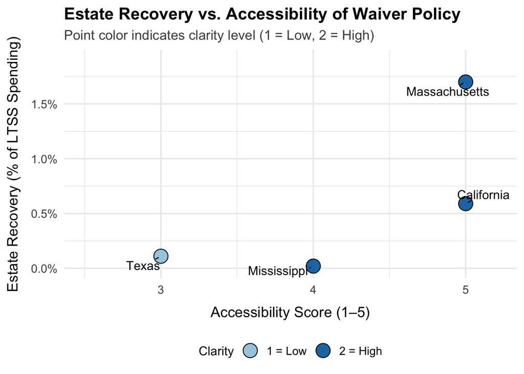

```r
#Figure 6
ggplot(MER_Data, aes(x = B_Accessibility,
                     y = `Estate Recovery % of LTSS Spending`,
                     fill = as.factor(C_Clarity),
                     label = State)) +
  geom_point(shape = 21, size = 6, color = "black", stroke = 0.6) +
  geom_text_repel(size = 4.2, point.padding = 0.3, min.segment.length = 0) +
  scale_fill_manual(
    values = c("1" = "#A6CEE3", "2" = "#1F78B4"),
    name = "Clarity",
    labels = c("1 = Low", "2 = High")
  ) +
  scale_x_continuous(breaks = 3:5, limits = c(2.5, 5.2)) +
  scale_y_continuous(labels = scales::percent_format(scale = 1, accuracy = 0.1),
                     limits = c(0, 1.9)) +
  labs(
    title = "Estate Recovery vs. Accessibility of Waiver Policy",
    subtitle = "Point color indicates clarity level (1 = Low, 2 = High)",
    x = "Accessibility Score (1–5)",
    y = "Estate Recovery (% of LTSS Spending)"
  ) +
  theme_minimal(base_size = 14) +
  theme(
    plot.title = element_text(face = "bold", size = 16),
    plot.subtitle = element_text(size = 13, color = "gray30"),
    axis.title.x = element_text(margin = margin(t = 10)),
    axis.title.y = element_text(margin = margin(r = 10)),
    legend.position = "bottom",
    legend.box = "horizontal",
    legend.title = element_text(size = 12),
    legend.text = element_text(size = 11)
  )
```

Page 26, Estate Recovery vs. Waiver Protectiveness Score

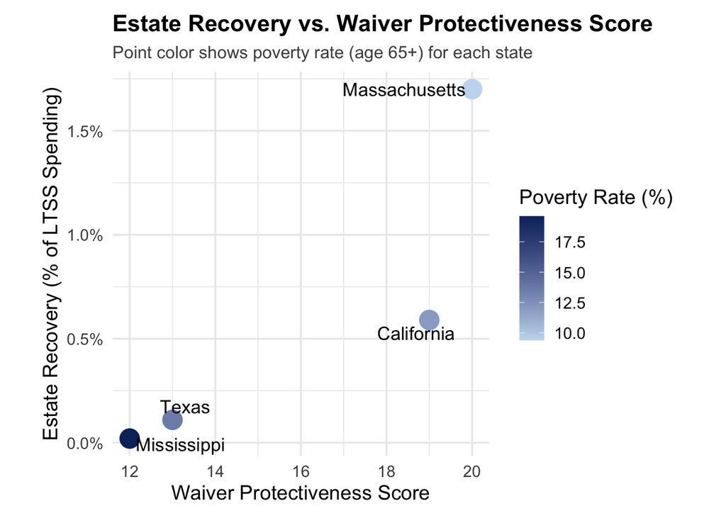

```r
# Figure 7
fig7 <- ggplot(MER_Data, aes(
  x = Waiver_Protectiveness_Score,
  y = `Estate Recovery % of LTSS Spending`,
  color = `Poverty Rate 65+ (%)`
)) +
  geom_point(size = 6) +
  geom_text_repel(aes(label = State), size = 4.5, color = "black") +
  scale_color_gradient(low = "#C6DBEF", high = "#08306B", name = "Poverty Rate (%)") +
  scale_y_continuous(labels = percent_format(scale = 1)) +
  labs(
    title = "Estate Recovery vs. Waiver Protectiveness Score",
    subtitle = "Point color shows poverty rate (age 65+) for each state",
    x = "Waiver Protectiveness Score",
    y = "Estate Recovery (% of LTSS Spending)"
  ) +
  theme_minimal(base_size = 14) +
  theme(
    plot.title = element_text(face = "bold", size = 16),
    plot.subtitle = element_text(size = 12, color = "gray30"),
    legend.position = "right",
    plot.margin = margin(10, 30, 10, 30)
  )

fig7
```